# IPCA

2022-06-26

## **IPCA nos últimos 12 meses**

O IPCA para o mês 05 foi de **0.47 %** e de acordo com o relatório Focus de 2022-04-29 o mercado espera uma **desaceleração** do IPCA mensal para os próximos 3 meses.

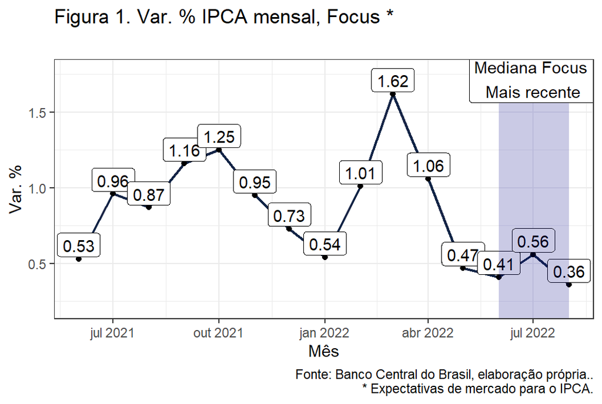

## **acumulado em 12 meses**

Em 12 meses o IPCA acumula uma variação de **11.73 %**.

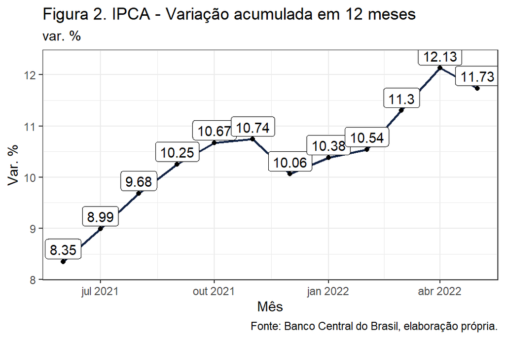

## **IPCA no último mês por Grupo**

Dentre os grupos que compõe IPCA o que apresentou maior crescimento foi o de **Vestuário** Com o percentual de **2.11 %** e o que apresentou menor crescimento foi o grupo **Habitação** Com o percentual de **-1.7 %**

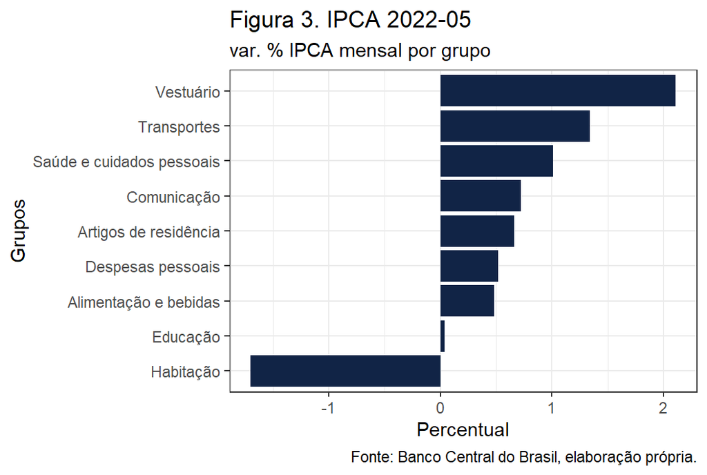

## **IPCA no último mês por Subitem**

Dos subitens que compõem o IPCA os três que mais contribuiram para o índice foram  
**Passagem aérea**, **Gasolina** e **Taxa de água e esgoto** que juntos contribuiram com **0.189** pontos percentuais de um total de **0.47**.

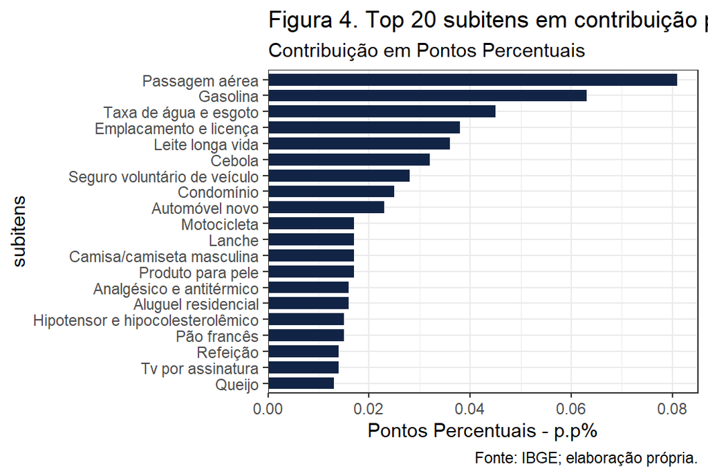

## **Maiores Variações no mês**

Dos subitens que compõem o IPCA os três com maior variação no mês foram  
**Cebola**, **Passagem aérea** e **Gás veicular** com variação de **21.36 %**, **18.33 %** e **14.88 %** respectivamente.

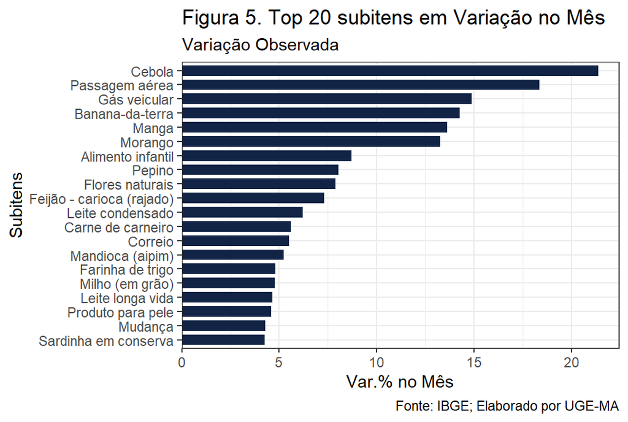

## **Maiores Variações no ano**

Dos subitens que compõem o IPCA os três com maior variação acumulada no ano corrente foram **Cenoura**, **Morango** e **Repolho** com variação de **90.07 %**, **82.54 %** e **66.29 %** respectivamente.

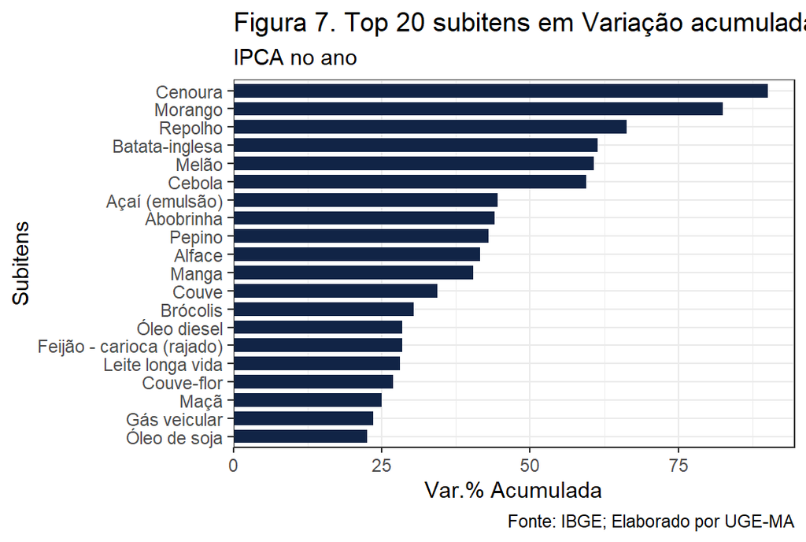

## **Maiores Variações em 12 meses**

Dos subitens que compõem o IPCA os três com maior variação acumulada em 12 meses foram  
**Cenoura**, **Passagem aérea** e **Abobrinha** com variação de **116.37 %**, **88.65 %** e **82.12 %** respectivamente.

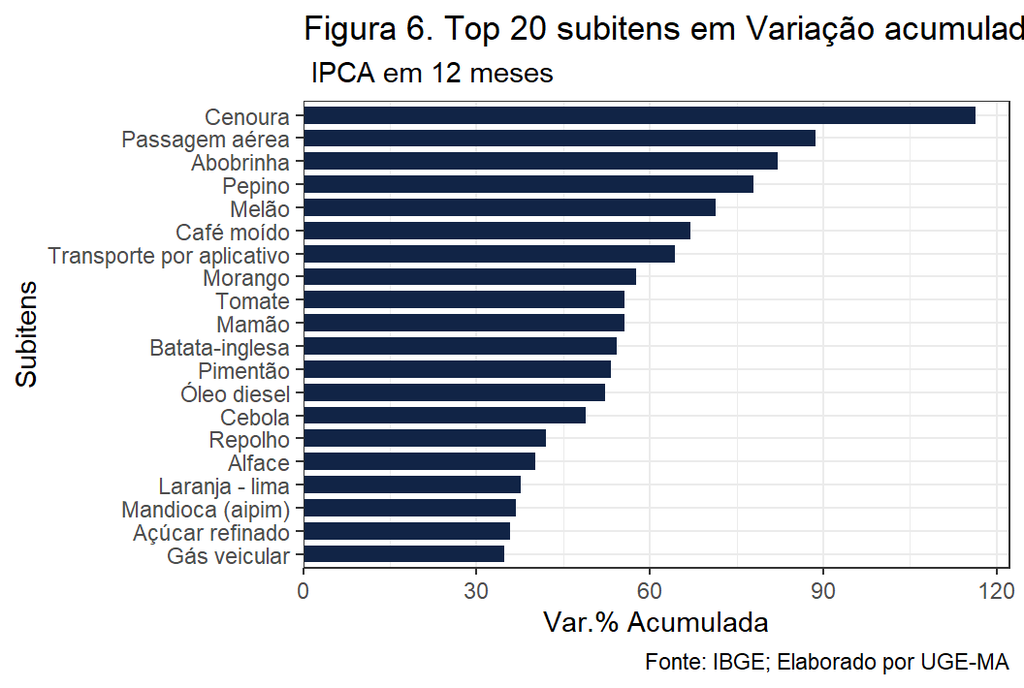